# 0.1 The Boston House Price Dataset

Classic Machine Learning Approaches

Rick Scavetta

# Boston Dataset

## Functions & Take-home Message

We’re going to focus on deep learning, but I want to put it in context with these methods that you should already be familiar with. You should be familiar with the concepts presented in this section.

## Load data

For this example, I’m going to use the exact same data that we’ll see later in deep learning so we can directly compare the results.

```r
# Read the dataset
boston <- read.csv("../data/boston_keras.csv")
```

We have 14 variables. The first 13 are the predictor variables and that last, `MEDV` is the response

| Variable | Description |
| --- | --- |
| `CRIM` | Per capita crime rate by town |
| `ZN` | Proportion of residential land zoned for lots over 25,000 sq.ft |
| `INDUS` | Proportion of non-retail business acres per town |
| `CHAS` | Charles River dummy variable (1 if tract bounds river; else 0) |
| `NOX` | Nitric oxides concentration (parts per 10 million) |
| `RM` | Average number of rooms per dwelling |
| `AGE` | Proportion of owner-occupied units built prior to 1940 |
| `DIS` | Weighted distances to five Boston employment centres |
| `RAD` | Index of accessibility to radial highways |
| `TAX` | Full-value property-tax rate per $10,000 |
| `PTRATIO` | Pupil-teacher ratio by town |
| `B` | $1000 * (Bk - 0.63)^2$ where $Bk$ is the proportion of blacks by town |
| `LSTAT` | % lower status of the population |
| `MEDV` | Median value of owner-occupied homes in $1000’s |

To give you an idea of the range of the data:

```r
summary(boston)
```

```
##       CRIM                ZN             INDUS            CHAS
##  Min.   : 0.00632   Min.   :  0.00   Min.   : 0.46   Min.   :0.00000
##  1st Qu.: 0.08204   1st Qu.:  0.00   1st Qu.: 5.19   1st Qu.:0.00000
##  Median : 0.25651   Median :  0.00   Median : 9.69   Median :0.00000
##  Mean   : 3.61352   Mean   : 11.36   Mean   :11.14   Mean   :0.06917
##  3rd Qu.: 3.67708   3rd Qu.: 12.50   3rd Qu.:18.10   3rd Qu.:0.00000
##  Max.   :88.97620   Max.   :100.00   Max.   :27.74   Max.   :1.00000
##       NOX               RM             AGE              DIS
##  Min.   :0.3850   Min.   :3.561   Min.   :  2.90   Min.   : 1.130
##  1st Qu.:0.4490   1st Qu.:5.886   1st Qu.: 45.02   1st Qu.: 2.100
##  Median :0.5380   Median :6.208   Median : 77.50   Median : 3.207
##  Mean   :0.5547   Mean   :6.285   Mean   : 68.57   Mean   : 3.795
##  3rd Qu.:0.6240   3rd Qu.:6.623   3rd Qu.: 94.08   3rd Qu.: 5.188
##  Max.   :0.8710   Max.   :8.780   Max.   :100.00   Max.   :12.127
##       RAD              TAX           PTRATIO            B
##  Min.   : 1.000   Min.   :187.0   Min.   :12.60   Min.   :  0.32
##  1st Qu.: 4.000   1st Qu.:279.0   1st Qu.:17.40   1st Qu.:375.38
##  Median : 5.000   Median :330.0   Median :19.05   Median :391.44
##  Mean   : 9.549   Mean   :408.2   Mean   :18.46   Mean   :356.67
##  3rd Qu.:24.000   3rd Qu.:666.0   3rd Qu.:20.20   3rd Qu.:396.23
##  Max.   :24.000   Max.   :711.0   Max.   :22.00   Max.   :396.90
##      LSTAT            MEDV
##  Min.   : 1.73   Min.   : 5.00
##  1st Qu.: 6.95   1st Qu.:17.02
##  Median :11.36   Median :21.20
##  Mean   :12.65   Mean   :22.53
##  3rd Qu.:16.95   3rd Qu.:25.00
##  Max.   :37.97   Max.   :50.00
```

## ML preparation

### Check Correlation

Each predictor variable against the response variable:

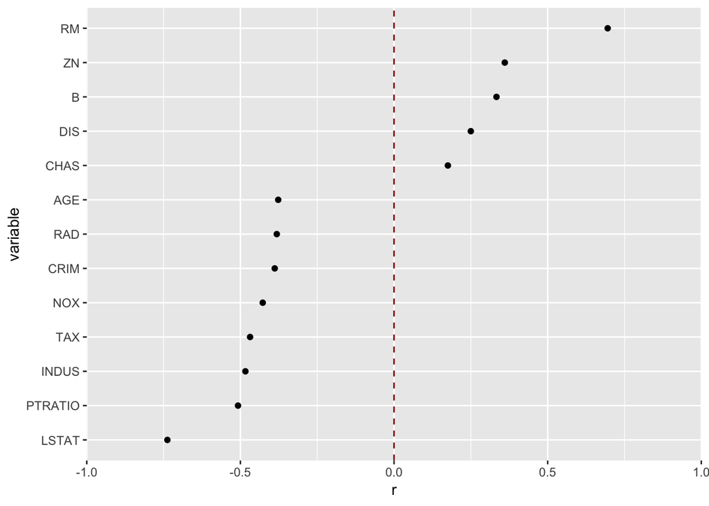

In practice we may decide, using criteria such as r, that some variables are more invormative. In this case we’ll just take all the variables.

### Check Variance

Assess presence of zero of near-zero variance variables:

```r
nzv <- nearZeroVar(boston, saveMetrics = TRUE)
```

There are 0 zero variance of near-zero variance variables.

### Create test set

This split reflects what we’ll see in `keras`.

```r
# as per the keras data set:
index <- 1:404

training <- boston[index,]
testing <- boston[-index,]
```

### Z-score Scaling

We’ll perform a Z-score transformation on each predictor variable, after splitting, as we will do later in deep learning. All variables will have a mean of 0.

```r
# Using dplyr to keep data frame structure:
training %>%
  mutate_at(vars(-MEDV), scale) -> training

testing %>%
  mutate_at(vars(-MEDV), scale) -> testing
```

## GLM

Linear models take the form:

$$Y_i = \beta_0 + \beta_1 X_{i1} + \beta_2 X_{i2} + \ldots + \beta_p X_{ip} + \epsilon_i$$
. The coefficients are:

Since we are assuming normal distributions, `glm()` and `lm()` perform the same. The coefficients:

```r
fit_lm <- lm(MEDV~.,data = training)
```

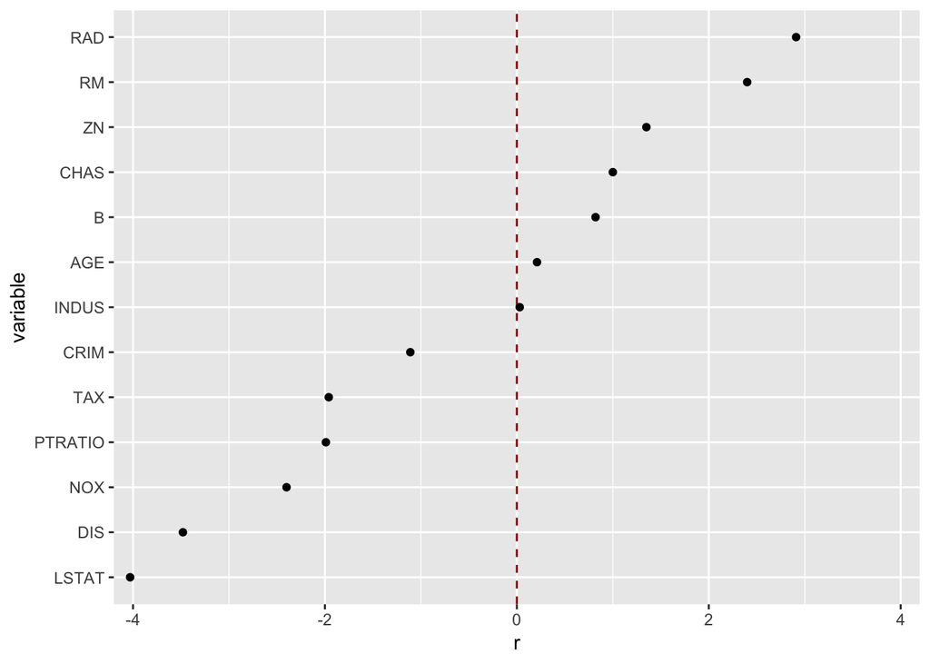

```r
#predict on test set
pred_lm <- predict(fit_lm, newdata = testing)

MAE_lm <- sum(abs(pred_lm - testing$MEDV))/102
```

Our measure for the error will be the mean absolute error (MAE):

$$\mathrm{MAE} = \frac{\sum_{i=1}^n\left| y_i-\hat{y_i}\right|}{n} = \frac{\sum_{i=1}^n\left| e_i\right|}{n}$$

$$\operatorname{MSE} = \frac{\sum_{i=1}^n(y_i-\hat{y_i})^2}{n} = \frac{\sum_{i=1}^n{e_i^2}}{n}$$

$$\operatorname{RMSE} = \sqrt{MSE}$$

the MSE will also make a reappearance in deep learning as our loss function.

The MAE, using the linear model, is 3.3162743. In dollar amounts, we are off by $3316.27.

## Random Forest

Let’s give it another go using a random forest.

```r
fit_rf <- randomForest(MEDV ~ ., data = training)

pred_rf <- predict(fit_rf, testing)

MAE_rf <- sum(abs(pred_rf - testing$MEDV))/102
```

In this case the MAE is 2.5384347. In dollar amounts, we are off by $2538, much better than before.

## Visualizing output

Let’s put this into context. The predictions for each model are compared to the actual data. The diagonal line is 1:1 equivalency.

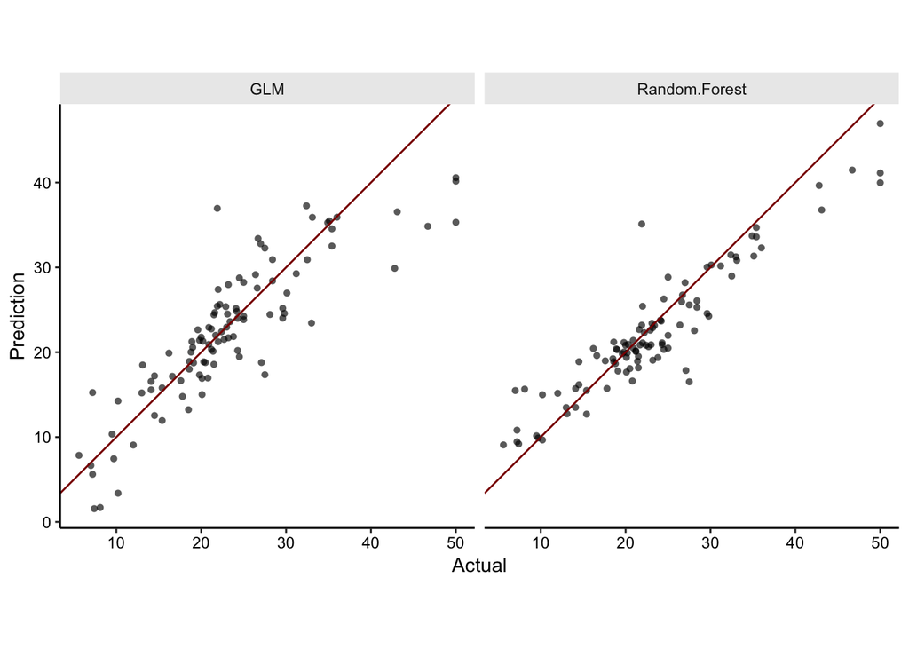

The results are saved in the `ClassicML.csv` file so that we can compare them with the results from deep learning.